# 5. Obesity Absolute Number with Tax Delta

### Importing necessary libraries

```python
import pandas as pd
import numpy as np
import seaborn as sns
import matplotlib.pyplot as plt
import statsmodels.api as sm

# code to ignore warnings
import warnings
warnings.filterwarnings("ignore")

root_csv = '../csv files/'
root_pickle = '../pickle files/'
```

### Reading files

```python
df_obese_total_pivot = pd.read_pickle(root_pickle +'Obesity_Total_Pivot.pkl')
df_obese_gender_pivot = pd.read_pickle(root_pickle +'Obesity_Gender_Pivot.pkl')
df_obese_age_pivot = pd.read_pickle(root_pickle +'Obesity_Age_Pivot.pkl')
```

### Reviewing data

```python
df_obese_total_pivot.head(5)
```

|  | State | County | CountyFIPS | Year | Total Absolute | Total Percentage | Grocery Tax | Restaurant Tax | tax_delta | Population |
| --- | --- | --- | --- | --- | --- | --- | --- | --- | --- | --- |
| 0 | Alabama | Autauga County | 1001 | 2004 | 7213.0 | 21.9 | 0.04 | 0.04 | 0.0 | 32936.073633 |
| 6 | Alabama | Autauga County | 1001 | 2005 | 8093.0 | 24.0 | 0.04 | 0.04 | 0.0 | 33720.833333 |
| 12 | Alabama | Autauga County | 1001 | 2006 | 7457.0 | 21.5 | 0.04 | 0.04 | 0.0 | 34683.720930 |
| 18 | Alabama | Autauga County | 1001 | 2007 | 7467.0 | 21.1 | 0.04 | 0.04 | 0.0 | 35388.624953 |
| 24 | Alabama | Autauga County | 1001 | 2008 | 9568.0 | 26.6 | 0.04 | 0.04 | 0.0 | 35969.924296 |

```python
df_obese_gender_pivot.head(5)
```

|  | State | County | CountyFIPS | Year | Gender Absolute | Gender Percentage | Gender | Grocery Tax | Restaurant Tax | tax_delta | Population |
| --- | --- | --- | --- | --- | --- | --- | --- | --- | --- | --- | --- |
| 0 | Alabama | Autauga County | 1001 | 2004 | 3747.0 | 21.700001 | Female | 0.04 | 0.04 | 0.0 | 17267.280499 |
| 3 | Alabama | Autauga County | 1001 | 2004 | 3466.0 | 22.100000 | Male | 0.04 | 0.04 | 0.0 | 15683.257648 |
| 6 | Alabama | Autauga County | 1001 | 2005 | 4141.0 | 23.400000 | Female | 0.04 | 0.04 | 0.0 | 17696.581485 |
| 9 | Alabama | Autauga County | 1001 | 2005 | 3952.0 | 24.600000 | Male | 0.04 | 0.04 | 0.0 | 16065.040401 |
| 12 | Alabama | Autauga County | 1001 | 2006 | 3874.0 | 21.299999 | Female | 0.04 | 0.04 | 0.0 | 18187.794079 |

```python
df_obese_age_pivot.head(5)
```

|  | State | County | CountyFIPS | Year | Age Obesity Absolute | Age Obesity Percentage | Age | Grocery Tax | Restaurant Tax | tax_delta | Population |
| --- | --- | --- | --- | --- | --- | --- | --- | --- | --- | --- | --- |
| 0 | Alabama | Autauga County | 1001 | 2004 | 3411.0 | 20.700001 | 20-44 | 0.04 | 0.04 | 0.0 | 16478.260262 |
| 1 | Alabama | Autauga County | 1001 | 2004 | 2898.0 | 25.299999 | 45-64 | 0.04 | 0.04 | 0.0 | 11454.545800 |
| 2 | Alabama | Autauga County | 1001 | 2004 | 904.0 | 17.900000 | 65-beyond | 0.04 | 0.04 | 0.0 | 5050.279437 |
| 6 | Alabama | Autauga County | 1001 | 2005 | 3714.0 | 22.200001 | 20-44 | 0.04 | 0.04 | 0.0 | 16729.729155 |
| 7 | Alabama | Autauga County | 1001 | 2005 | 3379.0 | 28.500000 | 45-64 | 0.04 | 0.04 | 0.0 | 11856.140351 |

### Regression Analysis at County level data

#### 1. Baseline without controls

##### a. With Total Absolute as Response Variable:

##### Note:

Even though Total Absolute does not make sense as concluded from EDA, we are carrying regression on it.

```python
import numpy as np
import pandas as pd
import statsmodels.api as sm
from sklearn.model_selection import train_test_split
from sklearn.linear_model import LinearRegression
from sklearn.metrics import mean_squared_error, r2_score

# Assuming 'Grocery Tax' and 'Restaurant Tax' are the features
X = df_obese_total_pivot['tax_delta']
y = df_obese_total_pivot['Total Absolute']

# Add a constant term to the features matrix (required for statsmodels)
X = sm.add_constant(X)

# Create and fit the linear regression model using statsmodels
stats_model = sm.OLS(y, X).fit()

# Print the summary
print(stats_model.summary())
```

```
                            OLS Regression Results
==============================================================================
Dep. Variable:         Total Absolute   R-squared:                       0.016
Model:                            OLS   Adj. R-squared:                  0.016
Method:                 Least Squares   F-statistic:                     890.0
Date:                Sun, 26 Nov 2023   Prob (F-statistic):          5.91e-194
Time:                        07:37:48   Log-Likelihood:            -6.6074e+05
No. Observations:               53352   AIC:                         1.321e+06
Df Residuals:                   53350   BIC:                         1.321e+06
Df Model:                           1
Covariance Type:            nonrobust
==============================================================================
                 coef    std err          t      P>|t|      [0.025      0.975]
------------------------------------------------------------------------------
const       7174.6364    471.020     15.232      0.000    6251.433    8097.840
tax_delta   2.985e+05      1e+04     29.832      0.000    2.79e+05    3.18e+05
==============================================================================
Omnibus:                    94804.055   Durbin-Watson:                   0.120
Prob(Omnibus):                  0.000   Jarque-Bera (JB):        167482403.612
Skew:                          12.730   Prob(JB):                         0.00
Kurtosis:                     276.299   Cond. No.                         40.0
==============================================================================

Notes:
[1] Standard Errors assume that the covariance matrix of the errors is correctly specified.
```

##### Conclusion:

The baseline model with response as total number of Obesity and predictor variables grocery tax and restaurant tax:

- One percent increase in tax delta, keeping all other constant, increases the absolute number by 2.98 x 10^5
- p-value is close to 0 in both cases. Hence the coefficients of regression are statistically significant
- Adjusted R-square is 0.016 indicating that the model can explain only 1.6% of variation in total number of Obesity patient
- Again, this model was fitted only on absolute numbers and we will switch to a more better approach of percentages.

#### 2. With single controls

##### a. Gender Control - On Absolute Number

```python
import numpy as np
import pandas as pd
import statsmodels.api as sm
from sklearn.model_selection import train_test_split
from sklearn.linear_model import LinearRegression
from sklearn.metrics import mean_squared_error, r2_score

# One Hot Encoding Gender in predictor variable
X = pd.get_dummies(df_obese_gender_pivot[['tax_delta', 'Gender']], columns=['Gender'], drop_first=True)
y = df_obese_gender_pivot['Gender Absolute']

# Add a constant term to the features matrix (required for statsmodels)
X = sm.add_constant(X)

# Create and fit the linear regression model using statsmodels
stats_model = sm.OLS(y, X).fit()

# Print the summary
print(stats_model.summary())
```

```
                            OLS Regression Results
==============================================================================
Dep. Variable:        Gender Absolute   R-squared:                       0.016
Model:                            OLS   Adj. R-squared:                  0.016
Method:                 Least Squares   F-statistic:                     885.6
Date:                Sun, 26 Nov 2023   Prob (F-statistic):               0.00
Time:                        07:37:48   Log-Likelihood:            -1.2479e+06
No. Observations:              106702   AIC:                         2.496e+06
Df Residuals:                  106699   BIC:                         2.496e+06
Df Model:                           2
Covariance Type:            nonrobust
===============================================================================
                  coef    std err          t      P>|t|      [0.025      0.975]
-------------------------------------------------------------------------------
const        3749.7801    189.357     19.803      0.000    3378.643    4120.917
tax_delta    1.493e+05   3551.191     42.048      0.000    1.42e+05    1.56e+05
Gender_Male  -311.7015    177.789     -1.753      0.080    -660.165      36.762
==============================================================================
Omnibus:                   189837.094   Durbin-Watson:                   0.070
Prob(Omnibus):                  0.000   Jarque-Bera (JB):        340421816.646
Skew:                          12.770   Prob(JB):                         0.00
Kurtosis:                     278.531   Cond. No.                         45.8
==============================================================================

Notes:
[1] Standard Errors assume that the covariance matrix of the errors is correctly specified.
```

##### Conclusion:

The model with response as total number of Obesity and predictor variables grocery tax and restaurant tax and control on gender:

- One percent increase in tax delta, keeping all other constant, increases the absolute number by 1.493 x 10^5
- If the gender is male, keeping all other constant, the absolute number decreases by 311.7015.
- p-value of gender male is >0.05. Hence the coefficients of regression of gender is not statistically significant
- Adjusted R-square is 0.016 indicating that the model can explain only 1.6% of variation in total number of Obesity patient
- Again, this model was fitted on absolute numbers and we will switch to a more better approach of percentages.

##### b. Age Control - On Absolute Number

```python
import numpy as np
import pandas as pd
import statsmodels.api as sm
from sklearn.model_selection import train_test_split
from sklearn.linear_model import LinearRegression
from sklearn.metrics import mean_squared_error, r2_score

# One Hot Encoding Gender in predictor variable
X = pd.get_dummies(df_obese_age_pivot[['tax_delta', 'Age']], columns=['Age'], drop_first=True)
y = df_obese_age_pivot['Age Obesity Absolute']

# Add a constant term to the features matrix (required for statsmodels)
X = sm.add_constant(X)

# Create and fit the linear regression model using statsmodels
stats_model = sm.OLS(y, X).fit()

# Print the summary
print(stats_model.summary())
```

```
                             OLS Regression Results
================================================================================
Dep. Variable:     Age Obesity Absolute   R-squared:                       0.025
Model:                              OLS   Adj. R-squared:                  0.025
Method:                   Least Squares   F-statistic:                     1369.
Date:                  Sun, 26 Nov 2023   Prob (F-statistic):               0.00
Time:                          07:37:48   Log-Likelihood:            -1.8180e+06
No. Observations:                159995   AIC:                         3.636e+06
Df Residuals:                    159991   BIC:                         3.636e+06
Df Model:                             3
Covariance Type:              nonrobust
=================================================================================
                    coef    std err          t      P>|t|      [0.025      0.975]
---------------------------------------------------------------------------------
const          4196.9838    122.486     34.265      0.000    3956.913    4437.055
tax_delta      9.951e+04   2079.463     47.856      0.000    9.54e+04    1.04e+05
Age_45-64      -484.1046    127.476     -3.798      0.000    -733.955    -234.255
Age_65-beyond -4931.7757    127.506    -38.679      0.000   -5181.686   -4681.866
==============================================================================
Omnibus:                   305878.883   Durbin-Watson:                   0.453
Prob(Omnibus):                  0.000   Jarque-Bera (JB):        953645940.026
Skew:                          14.782   Prob(JB):                         0.00
Kurtosis:                     380.064   Cond. No.                         44.6
==============================================================================

Notes:
[1] Standard Errors assume that the covariance matrix of the errors is correctly specified.
```

##### Conclusion:

The model with response as total number of Obesity and predictor variables grocery tax and restaurant tax and control on age:

- One percent increase in tax delta, keeping all other constant, increases the absolute number by 9.951 x 10^4
- If the age is between 45-64, keeping all other constant, the absolute number decreases by 484.
- If the age is between 65-beyond, keeping all other constant, the absolute number decreases by 4931.
- All p values are statistically significant
- Adjusted R-square is 0.025 indicating that the model can explain only 2.5% of variation in total number of Obesity patient
- Again, this model was fitted on absolute numbers and we will switch to a more better approach of percentages.

##### c. Total Population - On Absolute Number

```python
import numpy as np
import pandas as pd
import statsmodels.api as sm
from sklearn.model_selection import train_test_split
from sklearn.linear_model import LinearRegression
from sklearn.metrics import mean_squared_error, r2_score

# Assuming 'Grocery Tax' and 'Restaurant Tax' are the features
X = df_obese_total_pivot[['tax_delta','Population']]
y = df_obese_total_pivot['Total Absolute']

# Add a constant term to the features matrix (required for statsmodels)
X = sm.add_constant(X)

# Create and fit the linear regression model using statsmodels
stats_model = sm.OLS(y, X).fit()

# Print the summary
print(stats_model.summary())
```

```
                            OLS Regression Results
==============================================================================
Dep. Variable:         Total Absolute   R-squared:                       0.974
Model:                            OLS   Adj. R-squared:                  0.974
Method:                 Least Squares   F-statistic:                 1.011e+06
Date:                Sun, 26 Nov 2023   Prob (F-statistic):               0.00
Time:                        07:37:48   Log-Likelihood:            -5.6352e+05
No. Observations:               53352   AIC:                         1.127e+06
Df Residuals:                   53349   BIC:                         1.127e+06
Df Model:                           2
Covariance Type:            nonrobust
==============================================================================
                 coef    std err          t      P>|t|      [0.025      0.975]
------------------------------------------------------------------------------
const        760.8307     76.288      9.973      0.000     611.306     910.355
tax_delta   9016.9235   1630.456      5.530      0.000    5821.216    1.22e+04
Population     0.2451      0.000   1409.854      0.000       0.245       0.245
==============================================================================
Omnibus:                    24582.219   Durbin-Watson:                   0.370
Prob(Omnibus):                  0.000   Jarque-Bera (JB):         49679015.658
Skew:                           0.525   Prob(JB):                         0.00
Kurtosis:                     152.488   Cond. No.                     9.91e+06
==============================================================================

Notes:
[1] Standard Errors assume that the covariance matrix of the errors is correctly specified.
[2] The condition number is large, 9.91e+06. This might indicate that there are
strong multicollinearity or other numerical problems.
```

#### Conclusion:

The model with response as number of Obesity and predictor variable tax delta and control on population:

- One percent increase in tax delta, keeping all other constant, increases the Obesity number by 9016.
- One unit increase in population, keeping all other constant, increases the Obesity number by 0.2451.
- All p-value are statistically significant
- Adjusted R-square is 0.974 indicating that the model can explain only 97.4% of variation in total number of Obesity patient
- The conditional number is large and hence we need to check for multicollinearity
- This model has good R-square value but we need to validate the linearity assumptions and if any is violated, apply necessary trasformation

```python
# Checking for multicollinearity
from statsmodels.stats.outliers_influence import variance_inflation_factor

vif_data = pd.DataFrame()
vif_data["Variable"] = X.columns
vif_data["VIF"] = [variance_inflation_factor(X.values, i) for i in range(X.shape[1])]

# Check the VIF values
print(vif_data)
```

```
     Variable       VIF
0       const  3.549989
1   tax_delta  1.016110
2  Population  1.016110
```

##### Inference:

The VIF for predictor variables is small and hence multicollinearity does not exist. Scaling can fix the error if needed.

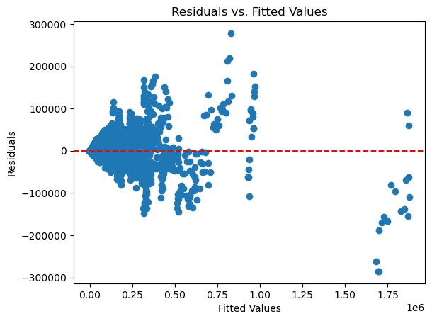

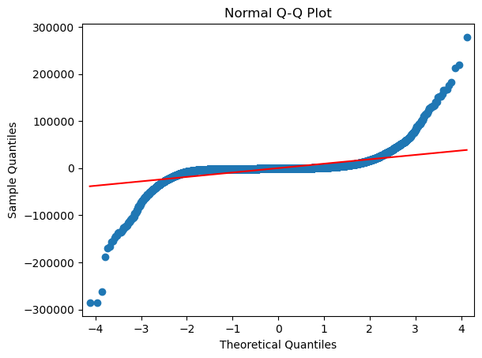

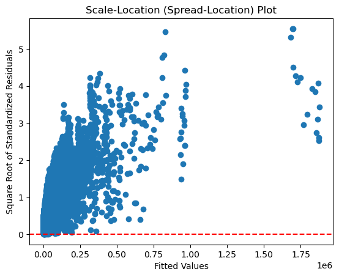

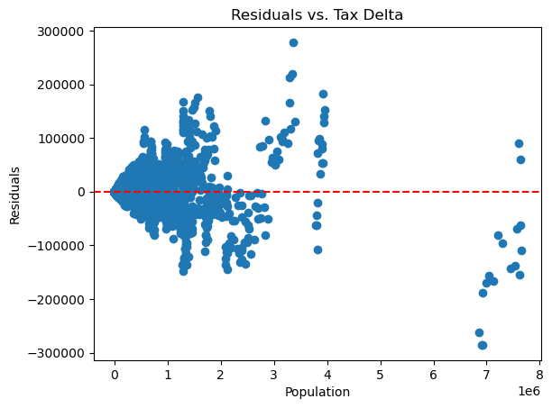

```python
# Validating for linearity assumptions

import statsmodels.api as sm
import matplotlib.pyplot as plt
import scipy.stats as stats
import numpy as np

# Assuming you have already fitted the linear regression model named 'model'

# Get fitted values and residuals
fitted_values = stats_model.fittedvalues
residuals = stats_model.resid

# 1. Residuals vs. Fitted Values Plot
plt.scatter(fitted_values, residuals)
plt.xlabel('Fitted Values')
plt.ylabel('Residuals')
plt.title('Residuals vs. Fitted Values')
plt.axhline(y=0, color='r', linestyle='--')  # Add a horizontal line at y=0
plt.show()

# 2. Normal Q-Q Plot
sm.qqplot(residuals, line='s')
plt.title('Normal Q-Q Plot')
plt.show()

# 3. Scale-Location (Spread-Location) Plot
sqrt_standardized_residuals = np.sqrt(np.abs(stats_model.get_influence().resid_studentized_internal))
plt.scatter(fitted_values, sqrt_standardized_residuals)
plt.xlabel('Fitted Values')
plt.ylabel('Square Root of Standardized Residuals')
plt.title('Scale-Location (Spread-Location) Plot')
plt.axhline(y=0, color='r', linestyle='--')  # Add a horizontal line at y=0
plt.show()

# 4. Residuals vs. Predictor Plot for ''
plt.scatter(df_obese_total_pivot['Population'], residuals)
plt.xlabel('Population')
plt.ylabel('Residuals')
plt.title('Residuals vs. Tax Delta')
plt.axhline(y=0, color='r', linestyle='--')  # Add a horizontal line at y=0
plt.show()
```

##### Inference:

Linearity assumptions are being violated. Lets apply Box-Cox transformations to fix that.

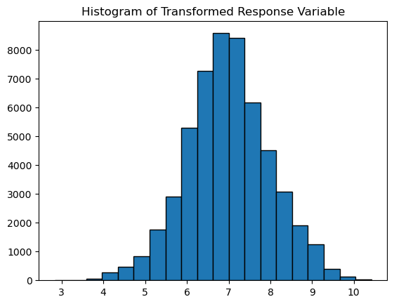

```
Lambda Value: -0.04831233596949974
                            OLS Regression Results
==============================================================================
Dep. Variable:                      y   R-squared:                       0.267
Model:                            OLS   Adj. R-squared:                  0.267
Method:                 Least Squares   F-statistic:                     9716.
Date:                Sun, 26 Nov 2023   Prob (F-statistic):               0.00
Time:                        07:37:52   Log-Likelihood:                -67464.
No. Observations:               53352   AIC:                         1.349e+05
Df Residuals:                   53349   BIC:                         1.350e+05
Df Model:                           2
Covariance Type:            nonrobust
==============================================================================
                 coef    std err          t      P>|t|      [0.025      0.975]
------------------------------------------------------------------------------
const          6.6410      0.007    950.072      0.000       6.627       6.655
tax_delta      4.8782      0.149     32.653      0.000       4.585       5.171
Population  2.076e-06   1.59e-08    130.327      0.000    2.04e-06    2.11e-06
==============================================================================
Omnibus:                    20967.099   Durbin-Watson:                   0.110
Prob(Omnibus):                  0.000   Jarque-Bera (JB):           334612.973
Skew:                          -1.466   Prob(JB):                         0.00
Kurtosis:                      14.913   Cond. No.                     9.91e+06
==============================================================================

Notes:
[1] Standard Errors assume that the covariance matrix of the errors is correctly specified.
[2] The condition number is large, 9.91e+06. This might indicate that there are
strong multicollinearity or other numerical problems.
```

```python
# Applying the Box-Cox transformation

# Apply Box-Cox Transformation to Response Variable
y_transformed, lambda_value = stats.boxcox(y + 1)  # Adding 1 to handle zero values

# Visualize the Transformed Response Variable
plt.hist(y_transformed, bins=20, edgecolor='black')
plt.title('Histogram of Transformed Response Variable')
plt.show()

# Check Lambda Value
print(f'Lambda Value: {lambda_value}')

# Fit a new model using the transformed response variable
stats_model_transformed = sm.OLS(y_transformed, X).fit()

# Print the summary of the transformed model
print(stats_model_transformed.summary())
```

##### Conclusion:

The model with response as number of Obesity and predictor variable tax delta and control on population:

- The lambda value is -0.048. Indicating the new model fit is on (((Obesity number^-0.048)-1)/-0.048). We will call this response as transformed y.
- One percent increase in tax delta, keeping all other constant, increases the transformed by 4.87
- One unit increase in population, keeping all other constant, increases the transformed y by 2.076 x 10^-6.
- All p-value are statistically significant
- Adjusted R-square is 0.267 indicating that the model can explain only 26.7% of variation in total number of Obesity patient
- To fix the conditional large number lets explore scaling.

```python
import statsmodels.api as sm
from sklearn.preprocessing import StandardScaler
import pandas as pd

df_obese_scaled = df_obese_total_pivot.reset_index(drop=True)
df_obese_scaled

# Extract the independent variables (features) from your DataFrame
X = df_obese_scaled[['tax_delta', 'Population']]

# Extract the dependent variable from your DataFrame
y = df_obese_scaled['Total Absolute']

# Initialize the StandardScaler
scaler = StandardScaler()

# Fit and transform the independent variables
X_scaled = scaler.fit_transform(X)

# Create a new DataFrame with the scaled features
X_scaled_df = pd.DataFrame(X_scaled, columns=X.columns)

# Add a constant term to the independent variables
X_scaled_df = sm.add_constant(X_scaled_df)

# Fit the linear regression model
model = sm.OLS(y, X_scaled_df).fit()

# Display the summary
print(model.summary())
```

```
                            OLS Regression Results
==============================================================================
Dep. Variable:         Total Absolute   R-squared:                       0.974
Model:                            OLS   Adj. R-squared:                  0.974
Method:                 Least Squares   F-statistic:                 1.011e+06
Date:                Sun, 26 Nov 2023   Prob (F-statistic):               0.00
Time:                        07:37:52   Log-Likelihood:            -5.6352e+05
No. Observations:               53352   AIC:                         1.127e+06
Df Residuals:                   53349   BIC:                         1.127e+06
Df Model:                           2
Covariance Type:            nonrobust
==============================================================================
                 coef    std err          t      P>|t|      [0.025      0.975]
------------------------------------------------------------------------------
const       1.908e+04     40.489    471.122      0.000     1.9e+04    1.92e+04
tax_delta    225.7154     40.814      5.530      0.000     145.719     305.712
Population  5.754e+04     40.814   1409.854      0.000    5.75e+04    5.76e+04
==============================================================================
Omnibus:                    24582.219   Durbin-Watson:                   0.370
Prob(Omnibus):                  0.000   Jarque-Bera (JB):         49679015.658
Skew:                           0.525   Prob(JB):                         0.00
Kurtosis:                     152.488   Cond. No.                         1.13
==============================================================================

Notes:
[1] Standard Errors assume that the covariance matrix of the errors is correctly specified.
```

##### Since the above model violates linearity assumptions, applying Box-Cox transformation to scaled parameters

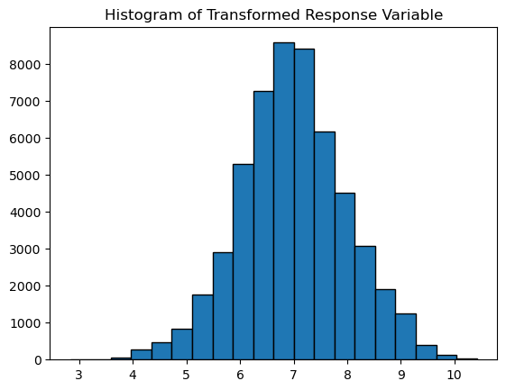

```
Lambda Value: -0.04831233596949974
                            OLS Regression Results
==============================================================================
Dep. Variable:                      y   R-squared:                       0.267
Model:                            OLS   Adj. R-squared:                  0.267
Method:                 Least Squares   F-statistic:                     9716.
Date:                Sun, 26 Nov 2023   Prob (F-statistic):               0.00
Time:                        07:37:52   Log-Likelihood:                -67464.
No. Observations:               53352   AIC:                         1.349e+05
Df Residuals:                   53349   BIC:                         1.350e+05
Df Model:                           2
Covariance Type:            nonrobust
==============================================================================
                 coef    std err          t      P>|t|      [0.025      0.975]
------------------------------------------------------------------------------
const          6.9876      0.004   1883.493      0.000       6.980       6.995
tax_delta      0.1221      0.004     32.653      0.000       0.115       0.129
Population     0.4874      0.004    130.327      0.000       0.480       0.495
==============================================================================
Omnibus:                    20967.099   Durbin-Watson:                   0.110
Prob(Omnibus):                  0.000   Jarque-Bera (JB):           334612.975
Skew:                          -1.466   Prob(JB):                         0.00
Kurtosis:                      14.913   Cond. No.                         1.13
==============================================================================

Notes:
[1] Standard Errors assume that the covariance matrix of the errors is correctly specified.
```

```python
# Applying the Box-Cox transformation

# Apply Box-Cox Transformation to Response Variable
y_transformed, lambda_value = stats.boxcox(y + 1)  # Adding 1 to handle zero values

# Visualize the Transformed Response Variable
plt.hist(y_transformed, bins=20, edgecolor='black')
plt.title('Histogram of Transformed Response Variable')
plt.show()

# Check Lambda Value
print(f'Lambda Value: {lambda_value}')

# Fit a new model using the transformed response variable
stats_model_transformed = sm.OLS(y_transformed, X_scaled_df).fit()

# Print the summary of the transformed model
print(stats_model_transformed.summary())
```

##### Conclusion:

The model with response as number of Obesity and predictor variable tax and control on population:

- The lambda value is -0.048. Indicating the new model fit is on (((Obesity number^-0.048)-1)/-0.048). We will call this response as transformed y.
- One percent increase in scaled tax delta, keeping all other constant, increases the transformed by 0.1221.
- One unit increase in scaled population, keeping all other constant, increases the transformed y by 0.4874.
- All p-value are statistically significant
- Adjusted R-square is 0.267 indicating that the model can explain only 26.7% of variation in total number of Obesity patient
- Conditonal large number error has been fixed

#### 3. With multiple controls

##### a. Total Population and Gender - On Absolute Number

```python
import numpy as np
import pandas as pd
import statsmodels.api as sm
from sklearn.model_selection import train_test_split
from sklearn.linear_model import LinearRegression
from sklearn.metrics import mean_squared_error, r2_score

# Assuming 'Grocery Tax' and 'Restaurant Tax' are the features
X = pd.get_dummies(df_obese_gender_pivot[['tax_delta','Population', 'Gender']], columns=['Gender'], drop_first=True)
y = df_obese_gender_pivot['Gender Absolute']

# Add a constant term to the features matrix (required for statsmodels)
X = sm.add_constant(X)

# Create and fit the linear regression model using statsmodels
stats_model = sm.OLS(y, X).fit()

# Print the summary
print(stats_model.summary())
```

```
                            OLS Regression Results
==============================================================================
Dep. Variable:        Gender Absolute   R-squared:                       0.973
Model:                            OLS   Adj. R-squared:                  0.973
Method:                 Least Squares   F-statistic:                 1.275e+06
Date:                Sun, 26 Nov 2023   Prob (F-statistic):               0.00
Time:                        07:37:52   Log-Likelihood:            -1.0563e+06
No. Observations:              106702   AIC:                         2.113e+06
Df Residuals:                  106698   BIC:                         2.113e+06
Df Model:                           3
Covariance Type:            nonrobust
===============================================================================
                  coef    std err          t      P>|t|      [0.025      0.975]
-------------------------------------------------------------------------------
const         294.4724     31.499      9.349      0.000     232.736     356.209
tax_delta    4300.1912    594.497      7.233      0.000    3134.985    5465.398
Population      0.2451      0.000   1939.516      0.000       0.245       0.245
Gender_Male   172.3178     29.528      5.836      0.000     114.444     230.192
==============================================================================
Omnibus:                    54216.109   Durbin-Watson:                   0.368
Prob(Omnibus):                  0.000   Jarque-Bera (JB):        109913507.540
Skew:                           0.807   Prob(JB):                         0.00
Kurtosis:                     160.225   Cond. No.                     4.97e+06
==============================================================================

Notes:
[1] Standard Errors assume that the covariance matrix of the errors is correctly specified.
[2] The condition number is large, 4.97e+06. This might indicate that there are
strong multicollinearity or other numerical problems.
```

##### Conclusion:

- One percent increase in tax delta, keeping all other constant, increases the Obesity number by 4300.
- One unit increase in population, keeping all other constant, increases the Obesity number by 0.2451
- If the gender is male, keeping all other constant, increases the Obesity number by 172.
- Adjusted R-square is 0.973 indicating that the model can explain only 97.3% of variation in total number of Obesity patient
- The conditional number is large and hence we need to check for multicollinearity
- This model has good R-square value but we need to validate the linearity assumptions and if any is violated, apply necessary trasformation

```python
# Checking for multicollinearity
from statsmodels.stats.outliers_influence import variance_inflation_factor

vif_data = pd.DataFrame()
vif_data["Variable"] = X.columns
vif_data["VIF"] = [variance_inflation_factor(X.values, i) for i in range(X.shape[1])]

# Check the VIF values
print(vif_data)
```

```
      Variable       VIF
0        const  4.552037
1    tax_delta  1.016073
2   Population  1.016145
3  Gender_Male  1.000071
```

##### Inference:

The VIF for predictor variables is small and hence multicollinearity does not exist. Scaling can fix the conditional large number error

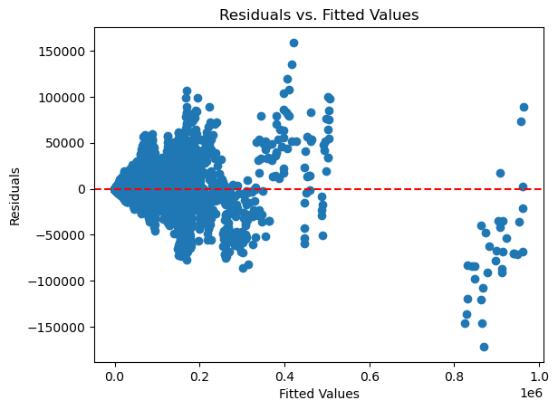

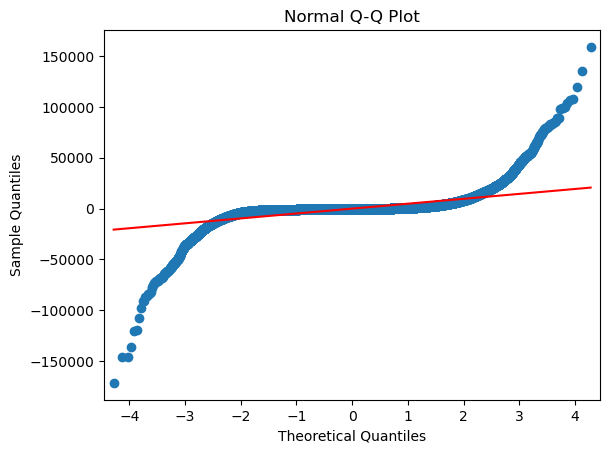

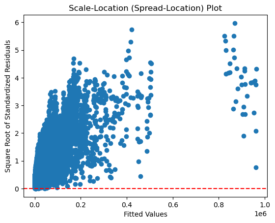

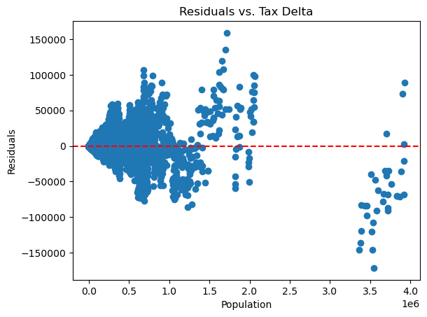

```python
# Validating for linearity assumptions

import statsmodels.api as sm
import matplotlib.pyplot as plt
import scipy.stats as stats
import numpy as np

# Assuming you have already fitted the linear regression model named 'model'

# Get fitted values and residuals
fitted_values = stats_model.fittedvalues
residuals = stats_model.resid

# 1. Residuals vs. Fitted Values Plot
plt.scatter(fitted_values, residuals)
plt.xlabel('Fitted Values')
plt.ylabel('Residuals')
plt.title('Residuals vs. Fitted Values')
plt.axhline(y=0, color='r', linestyle='--')  # Add a horizontal line at y=0
plt.show()

# 2. Normal Q-Q Plot
sm.qqplot(residuals, line='s')
plt.title('Normal Q-Q Plot')
plt.show()

# 3. Scale-Location (Spread-Location) Plot
sqrt_standardized_residuals = np.sqrt(np.abs(stats_model.get_influence().resid_studentized_internal))
plt.scatter(fitted_values, sqrt_standardized_residuals)
plt.xlabel('Fitted Values')
plt.ylabel('Square Root of Standardized Residuals')
plt.title('Scale-Location (Spread-Location) Plot')
plt.axhline(y=0, color='r', linestyle='--')  # Add a horizontal line at y=0
plt.show()

# 4. Residuals vs. Predictor Plot for ''
plt.scatter(df_obese_gender_pivot['Population'], residuals)
plt.xlabel('Population')
plt.ylabel('Residuals')
plt.title('Residuals vs. Tax Delta')
plt.axhline(y=0, color='r', linestyle='--')  # Add a horizontal line at y=0
plt.show()
```

##### Since the above model violates linearity assumptions, applying Box-Cox transoformation

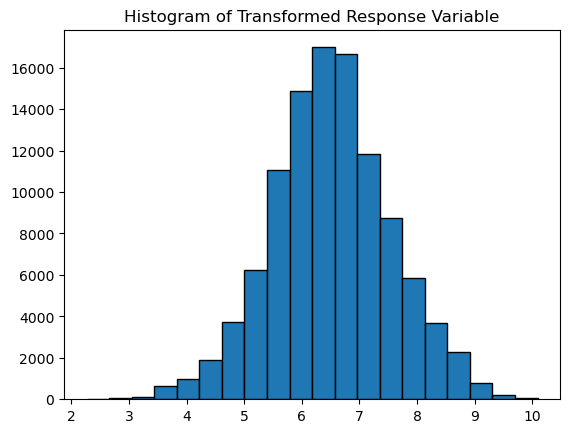

```
Lambda Value: -0.0484987596575893
                            OLS Regression Results
==============================================================================
Dep. Variable:                      y   R-squared:                       0.266
Model:                            OLS   Adj. R-squared:                  0.266
Method:                 Least Squares   F-statistic:                 1.292e+04
Date:                Sun, 26 Nov 2023   Prob (F-statistic):               0.00
Time:                        07:37:57   Log-Likelihood:            -1.3856e+05
No. Observations:              106702   AIC:                         2.771e+05
Df Residuals:                  106698   BIC:                         2.772e+05
Df Model:                           3
Covariance Type:            nonrobust
===============================================================================
                  coef    std err          t      P>|t|      [0.025      0.975]
-------------------------------------------------------------------------------
const           6.1451      0.006   1061.147      0.000       6.134       6.156
tax_delta       5.0280      0.109     46.002      0.000       4.814       5.242
Population   4.277e-06   2.32e-08    184.080      0.000    4.23e-06    4.32e-06
Gender_Male     0.0233      0.005      4.288      0.000       0.013       0.034
==============================================================================
Omnibus:                    41777.349   Durbin-Watson:                   0.064
Prob(Omnibus):                  0.000   Jarque-Bera (JB):           665176.941
Skew:                          -1.460   Prob(JB):                         0.00
Kurtosis:                      14.878   Cond. No.                     4.97e+06
==============================================================================

Notes:
[1] Standard Errors assume that the covariance matrix of the errors is correctly specified.
[2] The condition number is large, 4.97e+06. This might indicate that there are
strong multicollinearity or other numerical problems.
```

```python
# Applying the Box-Cox transformation

# Apply Box-Cox Transformation to Response Variable
y_transformed, lambda_value = stats.boxcox(y + 1)  # Adding 1 to handle zero values

# Visualize the Transformed Response Variable
plt.hist(y_transformed, bins=20, edgecolor='black')
plt.title('Histogram of Transformed Response Variable')
plt.show()

# Check Lambda Value
print(f'Lambda Value: {lambda_value}')

# Fit a new model using the transformed response variable
stats_model_transformed = sm.OLS(y_transformed, X).fit()

# Print the summary of the transformed model
print(stats_model_transformed.summary())
```

##### Conclusion:

- The lambda value is -0.048. Indicating the new model fit is on (((Obesity number^-0.048)-1)/-0.048). We will call this response as transformed y.
- One percent increase in scaled tax delta, keeping all other constant, increases the transformed by 5.028
- One unit increase in scaled population, keeping all other constant, increases the transformed y by 4.277 x 10^-6.
- All p-value are statistically significant
- Adjusted R-square is 0.266 indicating that the model can explain only 26.6% of variation in total number of Obesity patient
- Conditonal large number error still exists. Lets explore scaling to fix it.

```python
import statsmodels.api as sm
from sklearn.preprocessing import StandardScaler
import pandas as pd

df_obese_scaled = df_obese_gender_pivot.reset_index(drop=True)
df_obese_scaled

# Extract the independent variables (features) from your DataFrame
X = pd.get_dummies(df_obese_gender_pivot[['tax_delta','Population', 'Gender']], columns=['Gender'], drop_first=True)

# Extract the dependent variable from your DataFrame
y = df_obese_scaled['Gender Absolute']

# Initialize the StandardScaler
scaler = StandardScaler()

# Fit and transform the independent variables
X_scaled = scaler.fit_transform(X)

# Create a new DataFrame with the scaled features
X_scaled_df = pd.DataFrame(X_scaled, columns=X.columns)

# Add a constant term to the independent variables
X_scaled_df = sm.add_constant(X_scaled_df)

# Fit the linear regression model
model = sm.OLS(y, X_scaled_df).fit()

# Display the summary
print(model.summary())
```

```
                            OLS Regression Results
==============================================================================
Dep. Variable:        Gender Absolute   R-squared:                       0.973
Model:                            OLS   Adj. R-squared:                  0.973
Method:                 Least Squares   F-statistic:                 1.275e+06
Date:                Sun, 26 Nov 2023   Prob (F-statistic):               0.00
Time:                        07:37:57   Log-Likelihood:            -1.0563e+06
No. Observations:              106702   AIC:                         2.113e+06
Df Residuals:                  106698   BIC:                         2.113e+06
Df Model:                           3
Covariance Type:            nonrobust
===============================================================================
                  coef    std err          t      P>|t|      [0.025      0.975]
-------------------------------------------------------------------------------
const        9548.0467     14.763    646.736      0.000    9519.111    9576.983
tax_delta     107.6435     14.882      7.233      0.000      78.476     136.811
Population   2.886e+04     14.882   1939.516      0.000    2.88e+04    2.89e+04
Gender_Male    86.1589     14.764      5.836      0.000      57.222     115.096
==============================================================================
Omnibus:                    54216.109   Durbin-Watson:                   0.368
Prob(Omnibus):                  0.000   Jarque-Bera (JB):        109913507.547
Skew:                           0.807   Prob(JB):                         0.00
Kurtosis:                     160.225   Cond. No.                         1.14
==============================================================================

Notes:
[1] Standard Errors assume that the covariance matrix of the errors is correctly specified.
```

##### Since the above model violates linearity assumptions, applying Box-Cox transformation to scaled parameters

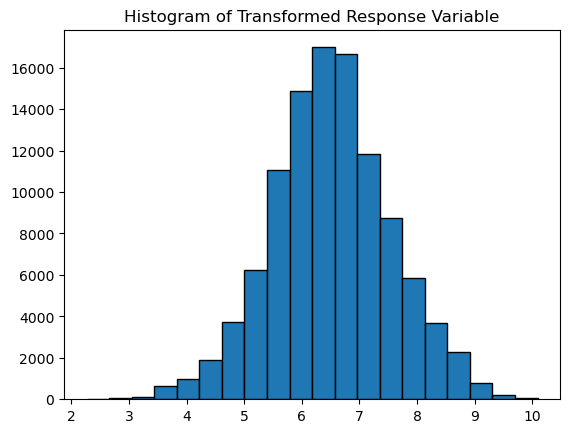

```
Lambda Value: -0.0484987596575893
                            OLS Regression Results
==============================================================================
Dep. Variable:                      y   R-squared:                       0.266
Model:                            OLS   Adj. R-squared:                  0.266
Method:                 Least Squares   F-statistic:                 1.292e+04
Date:                Sun, 26 Nov 2023   Prob (F-statistic):               0.00
Time:                        07:37:57   Log-Likelihood:            -1.3856e+05
No. Observations:              106702   AIC:                         2.771e+05
Df Residuals:                  106698   BIC:                         2.772e+05
Df Model:                           3
Covariance Type:            nonrobust
===============================================================================
                  coef    std err          t      P>|t|      [0.025      0.975]
-------------------------------------------------------------------------------
const           6.5142      0.003   2399.995      0.000       6.509       6.520
tax_delta       0.1259      0.003     46.002      0.000       0.120       0.131
Population      0.5037      0.003    184.080      0.000       0.498       0.509
Gender_Male     0.0116      0.003      4.288      0.000       0.006       0.017
==============================================================================
Omnibus:                    41777.349   Durbin-Watson:                   0.064
Prob(Omnibus):                  0.000   Jarque-Bera (JB):           665176.960
Skew:                          -1.460   Prob(JB):                         0.00
Kurtosis:                      14.878   Cond. No.                         1.14
==============================================================================

Notes:
[1] Standard Errors assume that the covariance matrix of the errors is correctly specified.
```

```python
# Applying the Box-Cox transformation

# Apply Box-Cox Transformation to Response Variable
y_transformed, lambda_value = stats.boxcox(y + 1)  # Adding 1 to handle zero values

# Visualize the Transformed Response Variable
plt.hist(y_transformed, bins=20, edgecolor='black')
plt.title('Histogram of Transformed Response Variable')
plt.show()

# Check Lambda Value
print(f'Lambda Value: {lambda_value}')

# Fit a new model using the transformed response variable
stats_model_transformed = sm.OLS(y_transformed, X_scaled_df).fit()

# Print the summary of the transformed model
print(stats_model_transformed.summary())
```

##### Conclusion:

The model with response as number of Obesity and predictor variable tax and population:

- The lambda value is -0.048. Indicating the new model fit is on (((Obesity number^-0.048)-1)/-0.048). We will call this response as transformed y.
- One percent increase in scaled tax delta, keeping all other constant, increases the transformed by 0.1259.
- One percent increase in scaled gender, keeping all other constant, increases the transformed by 0.0116.
- One unit increase in scaled population, keeping all other constant, increases the transformed y by 0.5037.
- All p-value are statistically significant
- Adjusted R-square is 0.266 indicating that the model can explain only 26.6% of variation in total number of Obesity patient
- Conditonal large number error has been fixed

##### b. Total Population and Age - On Absolute Number

```python
import numpy as np
import pandas as pd
import statsmodels.api as sm
from sklearn.model_selection import train_test_split
from sklearn.linear_model import LinearRegression
from sklearn.metrics import mean_squared_error, r2_score

# Assuming 'Grocery Tax' and 'Restaurant Tax' are the features
X = pd.get_dummies(df_obese_age_pivot[['tax_delta', 'Population','Age']], columns=['Age'], drop_first=True)
y = df_obese_age_pivot['Age Obesity Absolute']

# Add a constant term to the features matrix (required for statsmodels)
X = sm.add_constant(X)

# Create and fit the linear regression model using statsmodels
stats_model = sm.OLS(y, X).fit()

# Print the summary
print(stats_model.summary())
```

```
                             OLS Regression Results
================================================================================
Dep. Variable:     Age Obesity Absolute   R-squared:                       0.960
Model:                              OLS   Adj. R-squared:                  0.960
Method:                   Least Squares   F-statistic:                 9.710e+05
Date:                  Sun, 26 Nov 2023   Prob (F-statistic):               0.00
Time:                          07:37:58   Log-Likelihood:            -1.5616e+06
No. Observations:                159995   AIC:                         3.123e+06
Df Residuals:                    159990   BIC:                         3.123e+06
Df Model:                             4
Covariance Type:              nonrobust
=================================================================================
                    coef    std err          t      P>|t|      [0.025      0.975]
---------------------------------------------------------------------------------
const          -168.1872     24.776     -6.788      0.000    -216.748    -119.627
tax_delta      3887.0498    421.770      9.216      0.000    3060.390    4713.710
Population        0.2428      0.000   1944.908      0.000       0.243       0.243
Age_45-64      1485.0395     25.699     57.786      0.000    1434.670    1535.409
Age_65-beyond  -162.1152     25.802     -6.283      0.000    -212.687    -111.544
==============================================================================
Omnibus:                    80161.297   Durbin-Watson:                   1.385
Prob(Omnibus):                  0.000   Jarque-Bera (JB):        910500022.142
Skew:                           0.382   Prob(JB):                         0.00
Kurtosis:                     372.566   Cond. No.                     3.56e+06
==============================================================================

Notes:
[1] Standard Errors assume that the covariance matrix of the errors is correctly specified.
[2] The condition number is large, 3.56e+06. This might indicate that there are
strong multicollinearity or other numerical problems.
```

##### Conclusion:

The model with response as number of Obesity and predictor variable tax delta and control on age and population:

- One percent increase in tax delta, keeping all other constant, increases the Obesity number by 3887.
- One unit increase in population, keeping all other constant, increases the Obesity number by 0.2428
- Adjusted R-square is 0.96 indicating that the model can explain only 96% of variation in total number of Obesity patient
- The conditional number is large and hence we need to check for multicollinearity
- This model has good R-square value but we need to validate the linearity assumptions and if any is violated, apply necessary trasformation

```python
# Checking for multicollinearity
from statsmodels.stats.outliers_influence import variance_inflation_factor

vif_data = pd.DataFrame()
vif_data["Variable"] = X.columns
vif_data["VIF"] = [variance_inflation_factor(X.values, i) for i in range(X.shape[1])]

# Check the VIF values
print(vif_data)
```

```
        Variable       VIF
0          const  5.583687
1      tax_delta  1.013777
2     Population  1.022986
3      Age_45-64  1.335252
4  Age_65-beyond  1.345332
```

##### Inference:

The VIF for predictor variables is small and hence multicollinearity does not exist. Scaling can fix the conditionally large number error if needed.

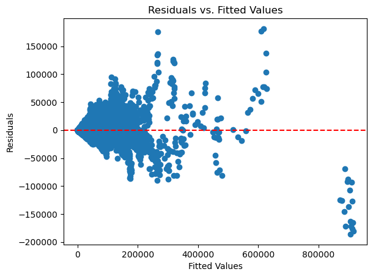

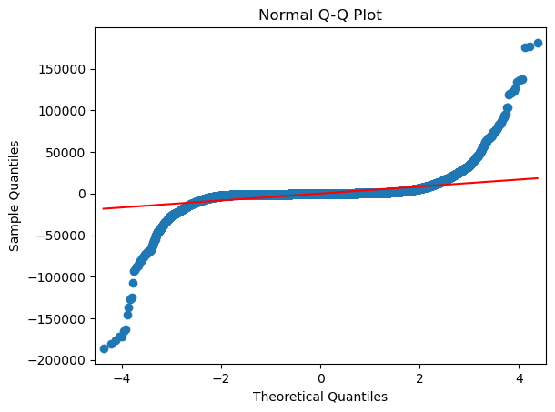

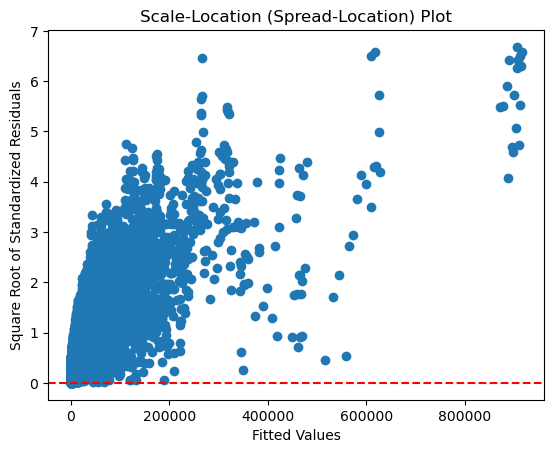

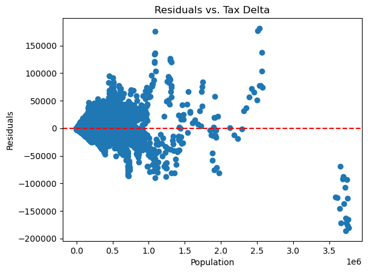

```python
# Validating for linearity assumptions

import statsmodels.api as sm
import matplotlib.pyplot as plt
import scipy.stats as stats
import numpy as np

# Assuming you have already fitted the linear regression model named 'model'

# Get fitted values and residuals
fitted_values = stats_model.fittedvalues
residuals = stats_model.resid

# 1. Residuals vs. Fitted Values Plot
plt.scatter(fitted_values, residuals)
plt.xlabel('Fitted Values')
plt.ylabel('Residuals')
plt.title('Residuals vs. Fitted Values')
plt.axhline(y=0, color='r', linestyle='--')  # Add a horizontal line at y=0
plt.show()

# 2. Normal Q-Q Plot
sm.qqplot(residuals, line='s')
plt.title('Normal Q-Q Plot')
plt.show()

# 3. Scale-Location (Spread-Location) Plot
sqrt_standardized_residuals = np.sqrt(np.abs(stats_model.get_influence().resid_studentized_internal))
plt.scatter(fitted_values, sqrt_standardized_residuals)
plt.xlabel('Fitted Values')
plt.ylabel('Square Root of Standardized Residuals')
plt.title('Scale-Location (Spread-Location) Plot')
plt.axhline(y=0, color='r', linestyle='--')  # Add a horizontal line at y=0
plt.show()

# 4. Residuals vs. Predictor Plot for ''
plt.scatter(df_obese_age_pivot['Population'], residuals)
plt.xlabel('Population')
plt.ylabel('Residuals')
plt.title('Residuals vs. Tax Delta')
plt.axhline(y=0, color='r', linestyle='--')  # Add a horizontal line at y=0
plt.show()
```

##### Since the above model violates linearity assumptions, applying Box-Cox transoformation

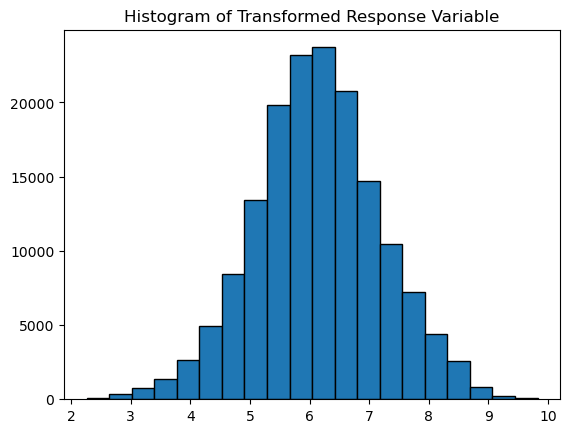

```
Lambda Value: -0.05081197153056619
                            OLS Regression Results
==============================================================================
Dep. Variable:                      y   R-squared:                       0.275
Model:                            OLS   Adj. R-squared:                  0.275
Method:                 Least Squares   F-statistic:                 1.514e+04
Date:                Sun, 26 Nov 2023   Prob (F-statistic):               0.00
Time:                        07:38:04   Log-Likelihood:            -2.1088e+05
No. Observations:              159995   AIC:                         4.218e+05
Df Residuals:                  159990   BIC:                         4.218e+05
Df Model:                           4
Covariance Type:            nonrobust
=================================================================================
                    coef    std err          t      P>|t|      [0.025      0.975]
---------------------------------------------------------------------------------
const             5.8599      0.005   1097.237      0.000       5.849       5.870
tax_delta         5.5253      0.091     60.775      0.000       5.347       5.703
Population     5.543e-06   2.69e-08    205.952      0.000    5.49e-06     5.6e-06
Age_45-64         0.1147      0.006     20.697      0.000       0.104       0.126
Age_65-beyond    -0.3518      0.006    -63.248      0.000      -0.363      -0.341
==============================================================================
Omnibus:                    67158.243   Durbin-Watson:                   0.183
Prob(Omnibus):                  0.000   Jarque-Bera (JB):          1675962.426
Skew:                          -1.467   Prob(JB):                         0.00
Kurtosis:                      18.582   Cond. No.                     3.56e+06
==============================================================================

Notes:
[1] Standard Errors assume that the covariance matrix of the errors is correctly specified.
[2] The condition number is large, 3.56e+06. This might indicate that there are
strong multicollinearity or other numerical problems.
```

```python
# Applying the Box-Cox transformation

# Apply Box-Cox Transformation to Response Variable
y_transformed, lambda_value = stats.boxcox(y + 1)  # Adding 1 to handle zero values

# Visualize the Transformed Response Variable
plt.hist(y_transformed, bins=20, edgecolor='black')
plt.title('Histogram of Transformed Response Variable')
plt.show()

# Check Lambda Value
print(f'Lambda Value: {lambda_value}')

# Fit a new model using the transformed response variable
stats_model_transformed = sm.OLS(y_transformed, X).fit()

# Print the summary of the transformed model
print(stats_model_transformed.summary())
```

##### Conclusion:

The model with response as number of Obesity and predictor variable tax delta and control on age and population:

- The lambda value is -0.05. Indicating the new model fit is on (((Obesity number^-0.05)-1)/-0.05). We will call this response as transformed y.
- One percent increase in tax delta, keeping all other constant, increases the transformed by 5.52.
- One unit increase in population, keeping all other constant, increases the transformed y by 5.543 x 10^-6.
- All p-value are statistically significant
- Adjusted R-square is 0.275 indicating that the model can explain only 27.5% of variation in total number of Obesity patient

```python
import statsmodels.api as sm
from sklearn.preprocessing import StandardScaler
import pandas as pd

df_obese_scaled = df_obese_age_pivot.reset_index(drop=True)
df_obese_scaled

# Extract the independent variables (features) from your DataFrame
X = pd.get_dummies(df_obese_scaled[['tax_delta','Population', 'Age']], columns=['Age'], drop_first=True)
# Extract the dependent variable from your DataFrame
y = df_obese_scaled['Age Obesity Absolute']

# Initialize the StandardScaler
scaler = StandardScaler()

# Fit and transform the independent variables
X_scaled = scaler.fit_transform(X)

# Create a new DataFrame with the scaled features
X_scaled_df = pd.DataFrame(X_scaled, columns=X.columns)

# Add a constant term to the independent variables
X_scaled_df = sm.add_constant(X_scaled_df)

# Fit the linear regression model
model = sm.OLS(y, X_scaled_df).fit()

# Display the summary
print(model.summary())
```

```
                             OLS Regression Results
================================================================================
Dep. Variable:     Age Obesity Absolute   R-squared:                       0.960
Model:                              OLS   Adj. R-squared:                  0.960
Method:                   Least Squares   F-statistic:                 9.710e+05
Date:                  Sun, 26 Nov 2023   Prob (F-statistic):               0.00
Time:                          07:38:04   Log-Likelihood:            -1.5616e+06
No. Observations:                159995   AIC:                         3.123e+06
Df Residuals:                    159990   BIC:                         3.123e+06
Df Model:                             4
Covariance Type:              nonrobust
=================================================================================
                    coef    std err          t      P>|t|      [0.025      0.975]
---------------------------------------------------------------------------------
const          6360.9100     10.485    606.665      0.000    6340.360    6381.460
tax_delta        97.2939     10.557      9.216      0.000      76.602     117.985
Population     2.063e+04     10.605   1944.908      0.000    2.06e+04    2.06e+04
Age_45-64       700.1178     12.116     57.786      0.000     676.371     723.864
Age_65-beyond   -76.4105     12.161     -6.283      0.000    -100.247     -52.574
==============================================================================
Omnibus:                    80161.297   Durbin-Watson:                   1.385
Prob(Omnibus):                  0.000   Jarque-Bera (JB):        910500022.232
Skew:                           0.382   Prob(JB):                         0.00
Kurtosis:                     372.566   Cond. No.                         1.75
==============================================================================

Notes:
[1] Standard Errors assume that the covariance matrix of the errors is correctly specified.
```

##### Since the above model violates linearity assumptions, applying Box-Cox transformation to scaled parameters

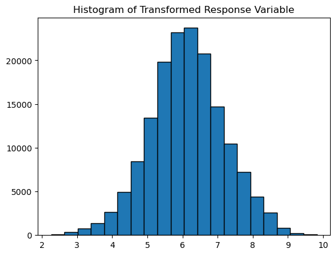

```
Lambda Value: -0.05081197153056619
                            OLS Regression Results
==============================================================================
Dep. Variable:                      y   R-squared:                       0.275
Model:                            OLS   Adj. R-squared:                  0.275
Method:                 Least Squares   F-statistic:                 1.514e+04
Date:                Sun, 26 Nov 2023   Prob (F-statistic):               0.00
Time:                        07:38:05   Log-Likelihood:            -2.1088e+05
No. Observations:              159995   AIC:                         4.218e+05
Df Residuals:                  159990   BIC:                         4.218e+05
Df Model:                           4
Covariance Type:            nonrobust
=================================================================================
                    coef    std err          t      P>|t|      [0.025      0.975]
---------------------------------------------------------------------------------
const             6.1367      0.002   2715.223      0.000       6.132       6.141
tax_delta         0.1383      0.002     60.775      0.000       0.134       0.143
Population        0.4708      0.002    205.952      0.000       0.466       0.475
Age_45-64         0.0541      0.003     20.697      0.000       0.049       0.059
Age_65-beyond    -0.1658      0.003    -63.248      0.000      -0.171      -0.161
==============================================================================
Omnibus:                    67158.244   Durbin-Watson:                   0.183
Prob(Omnibus):                  0.000   Jarque-Bera (JB):          1675962.520
Skew:                          -1.467   Prob(JB):                         0.00
Kurtosis:                      18.582   Cond. No.                         1.75
==============================================================================

Notes:
[1] Standard Errors assume that the covariance matrix of the errors is correctly specified.
```

```python
# Applying the Box-Cox transformation

# Apply Box-Cox Transformation to Response Variable
y_transformed, lambda_value = stats.boxcox(y + 1)  # Adding 1 to handle zero values

# Visualize the Transformed Response Variable
plt.hist(y_transformed, bins=20, edgecolor='black')
plt.title('Histogram of Transformed Response Variable')
plt.show()

# Check Lambda Value
print(f'Lambda Value: {lambda_value}')

# Fit a new model using the transformed response variable
stats_model_transformed = sm.OLS(y_transformed, X_scaled_df).fit()

# Print the summary of the transformed model
print(stats_model_transformed.summary())
```

##### Conclusion:

The model with response as number of Obesity and predictor variable tax and control on age and population:

- The lambda value is -0.05. Indicating the new model fit is on (((Obesity number^-0.05)-1)/-0.05). We will call this response as transformed y.
- One percent increase in scaled tax delta, keeping all other constant, increases the transformed by 0.1383.
- One unit increase in scaled population, keeping all other constant, increases the transformed y by 0.4708.
- All p-value are statistically significant
- Adjusted R-square is 0.275 indicating that the model can explain only 27.5% of variation in total number of Obesity patient
- Conditonal large number error has been fixed

### Final Conclusion:

- The best model for explaining Obesity Number variation with Tax, after accounting for necessary controls and corrections of assumptions, is the model with response, (((Obesity number^-0.05)-1)/-0.05); and scaled predictor tax delta, population and age control
- This model explains for 27.5% variability in Obesity number
- We shall continue to research the impact on Obesity percentage.